# STA380, Part 2: Exercises

Shreyansh Agarawal (sa55742), Praneet Kumar Alamuri (pa22222), Maanvi Goyal (mg65952), Prathmesh Savale (ps33296)

2022-08-15

*Link to github repository - https://github.com/praths007/STA-380-Part2*

## **Probability practice**|**Part A**

*Y* = a visitor clicked Yes.

*N* = a visitor clicked No.

*R* = a visitor is a random clicker.

*T* = a visitor is a truthful clicker

P(Y)= 0.65, P(N)= 0.35 , P(T)=0.7 , P(R)=0.3

P(Y|R)=0.5

P(N|R)=0.5

As per the law of total probability:

$$P(A)=P(A|B).P(B)+P(A|C).P(C)$$

The probability of people who answered *‘Yes’* can be calculated as:

$$P(Y)=P(Y|T).P(T)+P(Y|R).P(R)$$

$$0.65= P(Y∩T)+0.5*0.3$$

$$0.5=P(Y∩T)$$

Hence, there are **50%** of the people who are truthful clickers and answered ‘Yes’

$$5/7=P(T|Y)$$
Hence, there are **71.43%** of the people who are truthful clickers and given they answered ‘Yes’

## **Probability practice**|**Part B**

*P* = a person has tested positive

*N* = a person has tested negative

*D* = a person has a disease

*ND* = a person does not has a disease

P(D)= 0.000025, P(ND)= 0.999975 , P(P|D)=0.993 , P(N|ND)=0.9999

$$P(P|ND)+ P(N|ND)=1$$

P(P|ND)=1-P(N|ND)=1-0.9999

P(P|ND)=0.0001

As per the law of total probability:

$$P(A)=P(A|B).P(B)+P(A|C).P(C)$$

The probability of people who are positive can be calculated as:

$$P(P)=P(P|D).P(D)+P(P|ND).P(ND)$$

$$P(P)= (0.993)(0.000025)+(0.0001)(0.999975)$$

$$P(P)=0.00012482$$

As per Naive Bayes Theorem:

$$P(A|B)=[P(B|A).P(A)]/P(B)$$

The probability of people who have disease when they tested positive is:

$$P(D|P)=[P(P|D).P(D)]/P(P)$$

$$P(D|P)= [(0.993)(0.000025)]/(0.00012482)$$

$$P(D|P)=0.19888$$
Hence, the probability of people who have disease when they tested positive is **19.88%**

## **Wrangling the Billboard Top 100**|**Part A**

```
## [1] "Below table highlights the 10 most popular songs sung by various performers since 1958 on the Billboard Top 100"
```

```
## # A tibble: 10 × 3
## # Groups:   song [10]
##    song                                performer                           count
##    <chr>                               <chr>                               <int>
##  1 Radioactive                         Imagine Dragons                        87
##  2 Sail                                AWOLNATION                             79
##  3 Blinding Lights                     The Weeknd                             76
##  4 I'm Yours                           Jason Mraz                             76
##  5 How Do I Live                       LeAnn Rimes                            69
##  6 Counting Stars                      OneRepublic                            68
##  7 Party Rock Anthem                   LMFAO Featuring Lauren Bennett & G…    68
##  8 Foolish Games/You Were Meant For Me Jewel                                  65
##  9 Rolling In The Deep                 Adele                                  65
## 10 Before He Cheats                    Carrie Underwood                       64
```

## **Wrangling the Billboard Top 100**|**Part B**

```
## [1] "Below line chart represents the musical diversity of given year as the number of unique songs that appeared in the Billboard Top 100 that year"
```

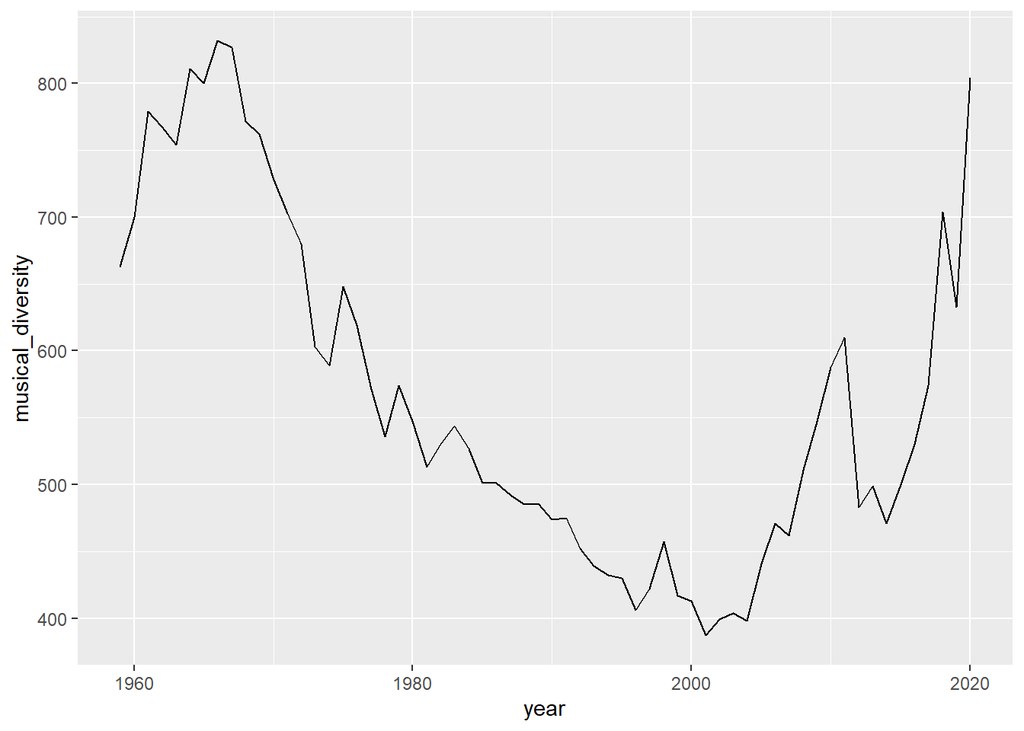

## **Wrangling the Billboard Top 100**|**Part C**

```
## [1] "Below bar plot represents 19 artists in U.S. musical history since 1958 who have had at least 30 songs that were ten-week hits"
```

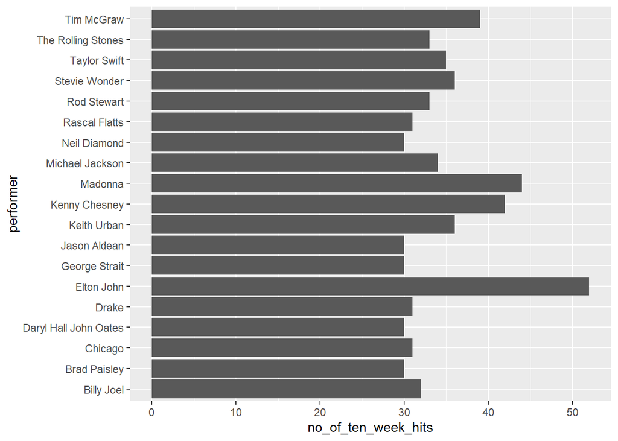

## **Visual story telling part 1: green buildings**

The excel guru had the following methodology -

- Removing the outliers i.e. buildings with less than 10% occupancy which resulted in median rent for non-green houses = $25 , green houses = $27.60 .
- The difference in rent per square foot is: $2.60 which is resulting in an added revenue of $650,000
- Now, the extra cost in $5,000,000 for a green building certification and hence the cost can be recovered in approximately ~8 years, and then on, there will be a net profit of $650,000 per year.

Although the calculations look reasonable, there are a few things that the excel guru has missed which we can now take a look into:

We are using median rent as we can see from the distribution that we have a right tail which will skew our mean.

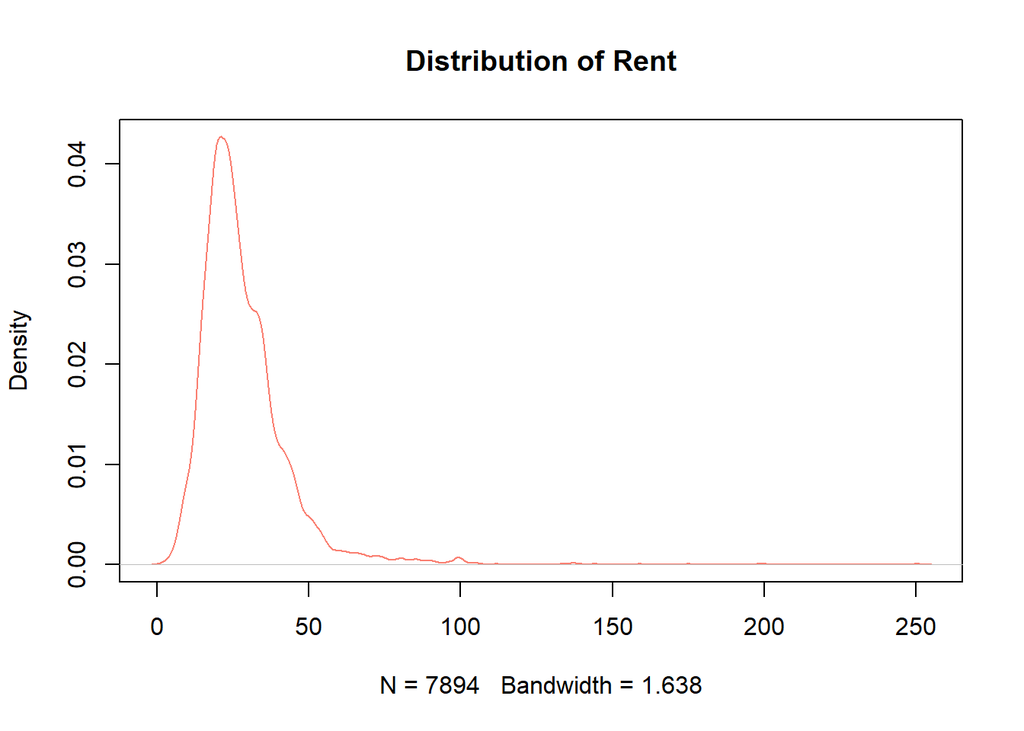

**Looking into house classes**

Class A Houses

- When we look into the proportion of Class A houses in non-green and green houses, we see that about 80% of the green houses are Class A as opposed to only ~35% in non-green houses
- There may be the case that the median rent for green-house are higher just because they have a higher proportion of Class A houses
- Let’s look into the median rent for Class A houses

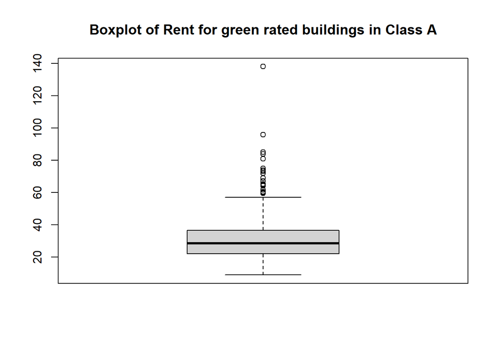

  ```
  ## [1] 28.44
  ```

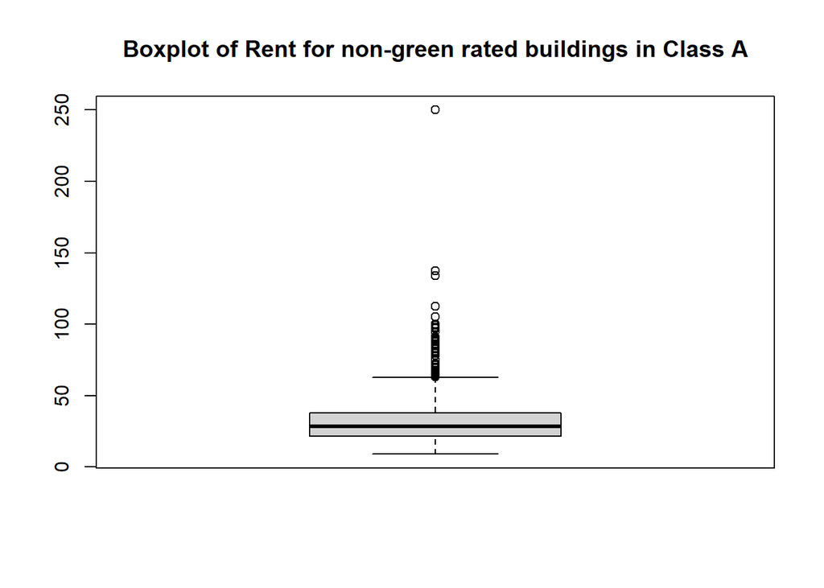

  ```
  ## [1] 28.2
  ```

  - Class A Overall : 28.2
  - Class A | Green: 28.44
  - Class A | Non-Green: 28.2
  - As we can see that, the rent of Class A houses does not depend on whether the house is green rating certified or not
  - So, if we compare a Class A non-green house and a Class A green house, there isn’t much difference in rent; only 0.2 per square feet i.e. just $50,000 extra premium per year

Class B Houses

- Let’s look into the median rent for Class B houses

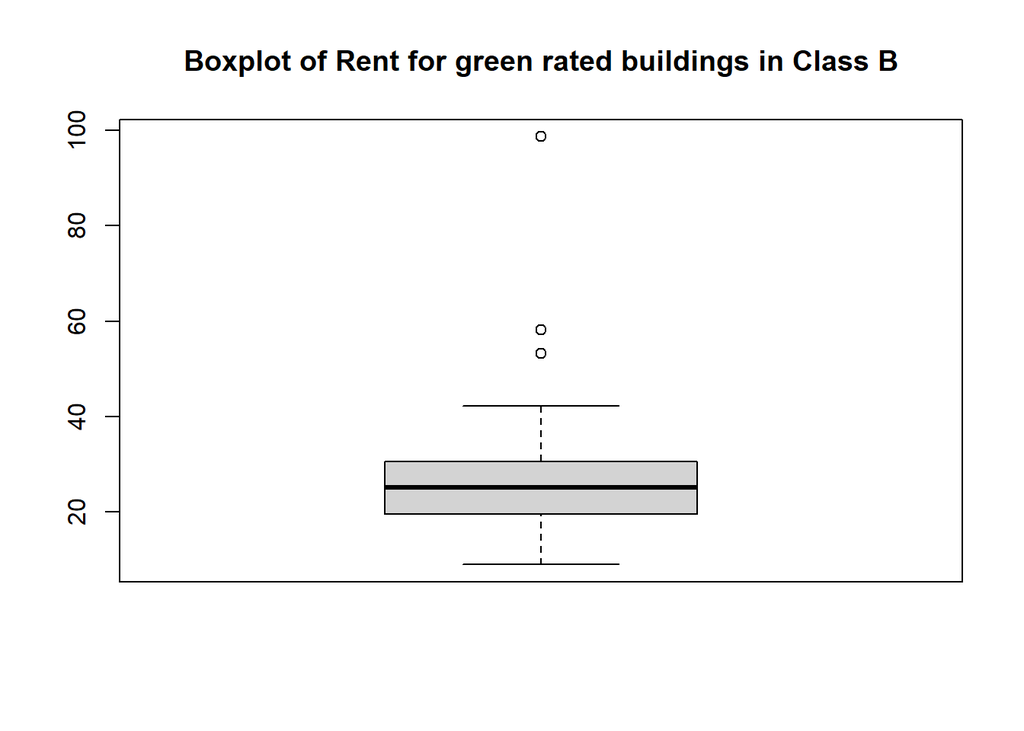

  ```
  ## [1] 25.1
  ```

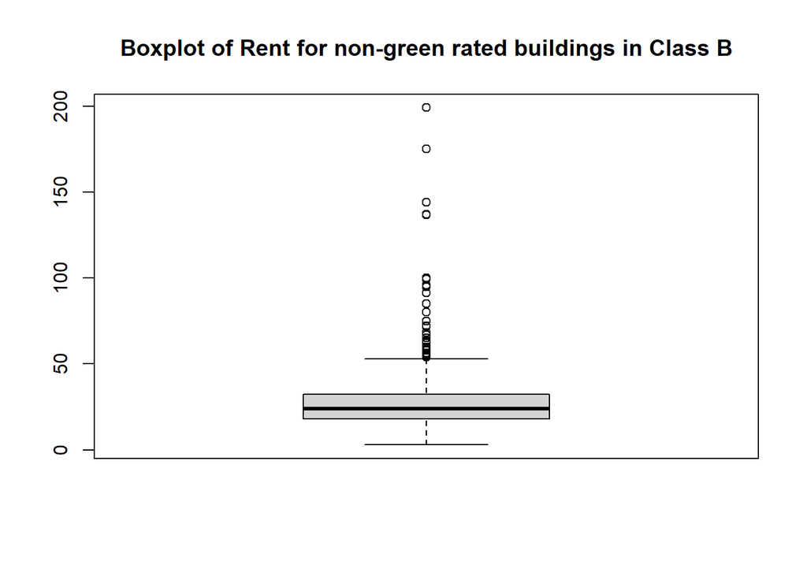

  ```
  ## [1] 24
  ```

  - Class B Overall : 24.0
  - Class B | Green: 25.1
  - Class B | Non-Green: 24.0
  - As we can see that the rent for Class B Green house is slightly higher than Class B non-green house, i.e. ~1.1 higher rent per square feet, which translates to ~275,000 extra premium per year.
  - If there is $5,000,000 extra cost for green certification, at 90% occupancy rate, it might take about 20 years to break even, and then the building can earn ~275,000 extra premium per year.

Class C Houses

Looking into Class C houses rent for green houses, we see that the rent for green building Class C houses are more than Class A and B which does not make sense. This might be due to very few green buildings belonging to Class C and hence we cannot rely on the median/ mean rent.

*Overall, based on house class, if we compare Class A houses, then there isn’t any cost benefit in getting a green building certification.*

*For Class B houses,* *there is some cost benefit but again, it’ll take ~20 years to break even and does not sound like a very viable option. But again, it depends on the builder if for them a time span of 20 years sound economically viable.*

**Looking into Amenities**

Since, ~75% of green rated buildings have good amenities (amenities=1), let’s compare the median rent amongst such buildings by class.

Class A buildings with amenities:

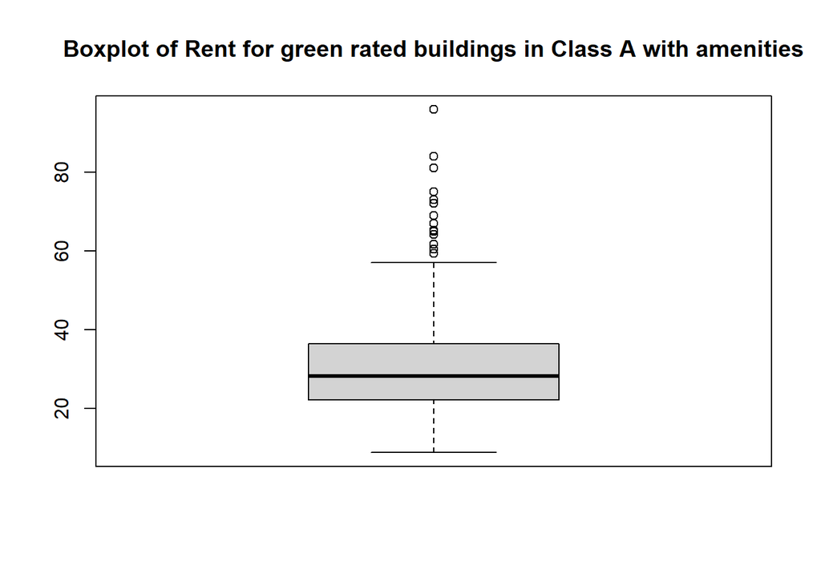

```
## [1] 28.2
```

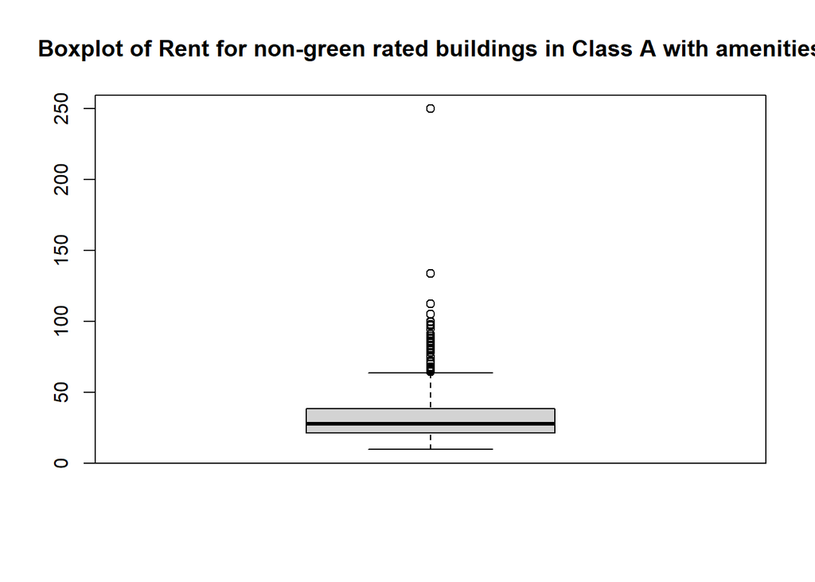

```
## [1] 27.73
```

Class B buildings with amenities:

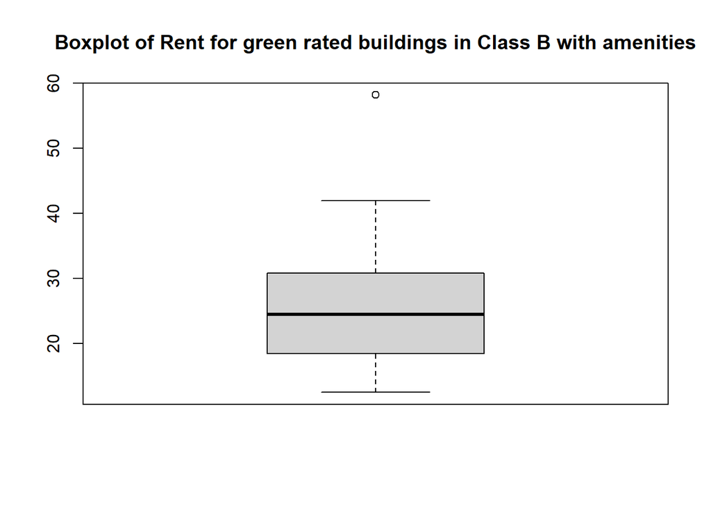

```
## [1] 24.46
```

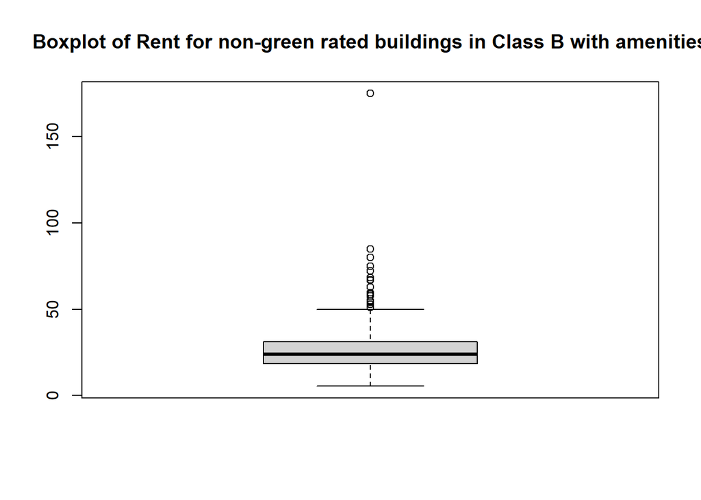

```
## [1] 23.89
```

**Hence based on our analysis and looking into House class, amenities etc. we can see that there isn’t much premium for buildings with green rating. In nutshell, we can say that green building status isn’t the only factor that is contributing to the “extra perceived” rent when we compare green buildings and non-green buildings, and hence we need to consider all the variables to make an informed estimate for the same.**

## **Visual story telling part 2: Capital Metro data**

Let’s look into how the the boarding varies by each day…

As you can see from the chart below is that traffic during Saturday and Sunday is very low as compared to weekdays which makes sense as since classes are not conducted during weekends, less students are near the UT area and hence the lower traffic.

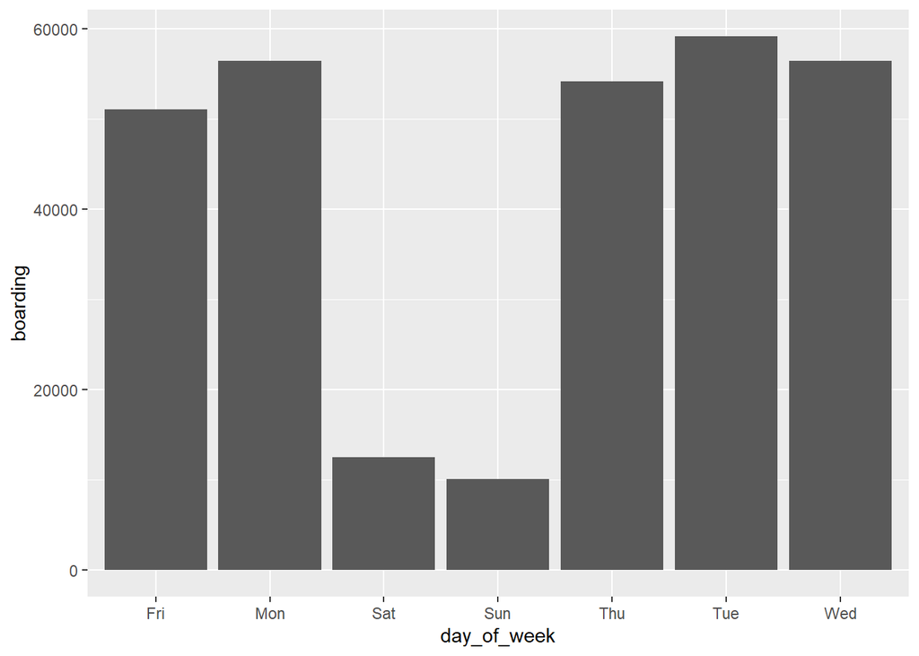

Now lets’s observe if the traffic varies by the time of day (all days combined)…

From the graph below, we can see high traffic during 2PM to 6PM, and highest traffic during 3PM to 5PM which makes sense as students return from campus during 3-5 PM the most. Post 6PM the traffic tapers off as less and less students are near the campus area.

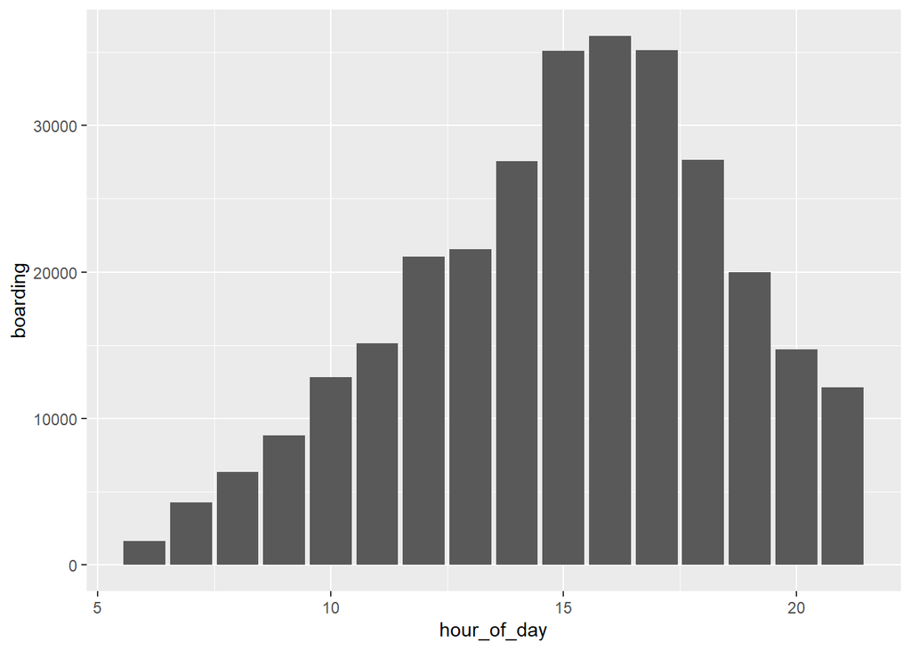

Now let’s look into the traffic by hours during the weekdays…

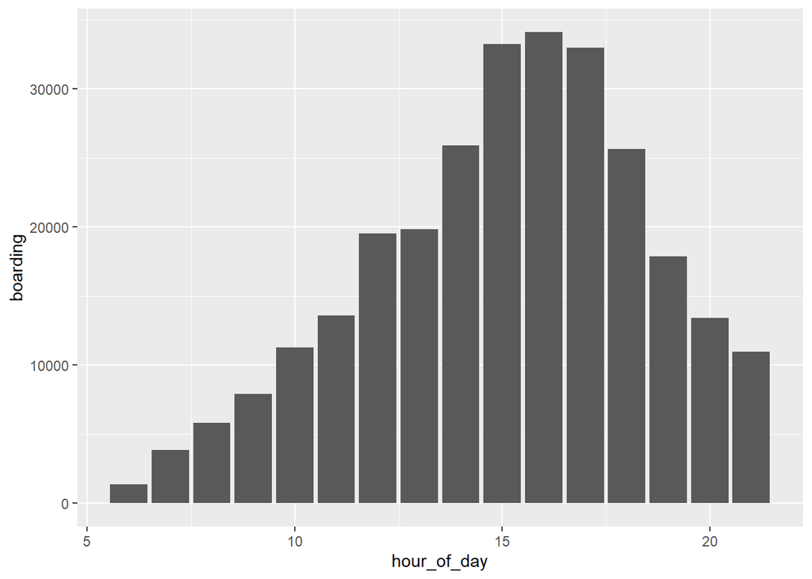

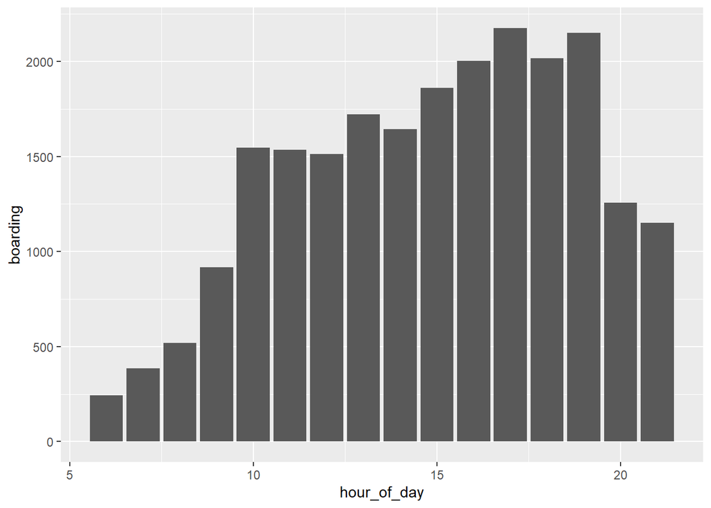

Now, let’s check if there is any relation b/w traffic and temperature.

From the scatter plot we can see there is no clear trend b/w temperature and traffic in the UT area. I guess because you have to attend class irrespective of the temperature.

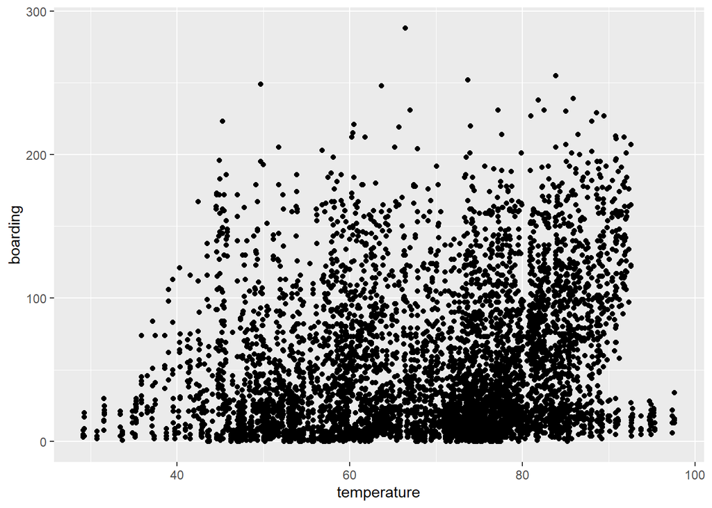

Now lets’ check if the traffic changes by months…

Form the plot below, we can see that there is slightly higher traffic during October.

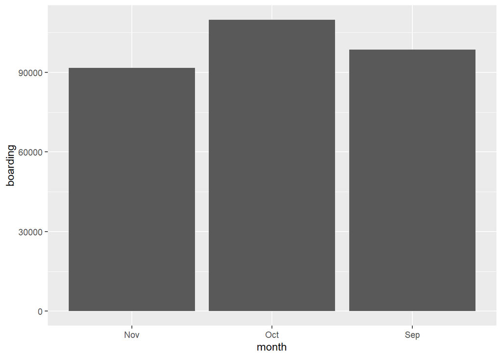

## **Portfolio modeling**

We have created 2 portfolios using the $100,00 and assessed the performance in a span of 20 days using the bootstrap re sampling. Additionally, we have assumed that our portfolio is re balanced each day at zero transaction cost.

**Portfolio 1:**

The first portfolio that we have is slightly conservative i.e. low risk and low return which comprises of 5 large cap stocks with equal distribution. We have 3 stocks from Pharama giants i.e. Pfizer, Novartis and Johnson & Johnson, and two large cap funds, Nestle and JP Morgan & Chase. The idea is to select strong companies which are less likely to fall to create a conservative portfolio.

Below is the profit simulation using bootstrap re-sampling.

We got a expected (mean) return of $950 and we are 95% confident that our loss in 20 day period won’t exceed $6,834 i.e our VaR at 5%.

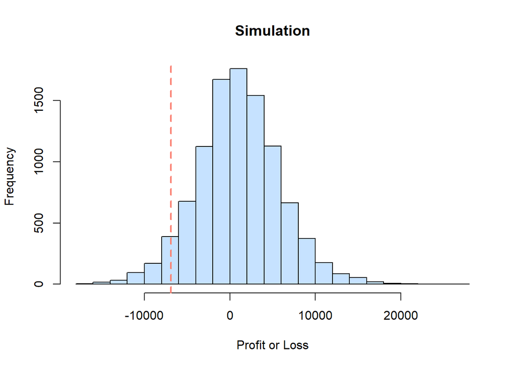

**Portfolio 2:**

Our 2nd portfolio is a bit more risky, with relatively high risk and high return compared to the first portfolio.

We have a mix of large and mid cap funds from different industries such as banking, entertainment , oil & gas which is exposing us to a variety of risks and market trends. Below is our portfolio and $100,000 is equally distributed amongst these stocks.

ASML -> ASML Holding N.V.

GS-> Goldman Sachs Group Inc.

MTDR-> Matador Resources Company

AX-> Axos Financial Inc

CZR-> Caesars Entertainment, Inc.

Below is the profit simulation using bootstrap re-sampling.

We got a expected (mean) return of $2,727 and we are 95% confident that our loss in 20 day period won’t exceed $15,697 i.e our VaR at 5%.

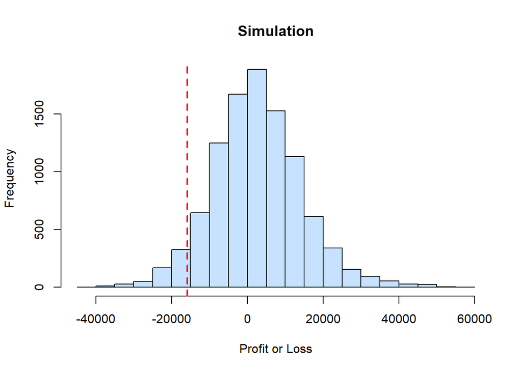

```
##     chatter       current_events      travel       photo_sharing
##  Min.   : 0.000   Min.   :0.000   Min.   : 0.000   Min.   : 0.000
##  1st Qu.: 2.000   1st Qu.:1.000   1st Qu.: 0.000   1st Qu.: 1.000
##  Median : 3.000   Median :1.000   Median : 1.000   Median : 2.000
##  Mean   : 4.399   Mean   :1.526   Mean   : 1.585   Mean   : 2.697
##  3rd Qu.: 6.000   3rd Qu.:2.000   3rd Qu.: 2.000   3rd Qu.: 4.000
##  Max.   :26.000   Max.   :8.000   Max.   :26.000   Max.   :21.000
##  uncategorized      tv_film      sports_fandom       politics
##  Min.   :0.000   Min.   : 0.00   Min.   : 0.000   Min.   : 0.000
##  1st Qu.:0.000   1st Qu.: 0.00   1st Qu.: 0.000   1st Qu.: 0.000
##  Median :1.000   Median : 1.00   Median : 1.000   Median : 1.000
##  Mean   :0.813   Mean   : 1.07   Mean   : 1.594   Mean   : 1.789
##  3rd Qu.:1.000   3rd Qu.: 1.00   3rd Qu.: 2.000   3rd Qu.: 2.000
##  Max.   :9.000   Max.   :17.00   Max.   :20.000   Max.   :37.000
##       food            family        home_and_garden      music
##  Min.   : 0.000   Min.   : 0.0000   Min.   :0.0000   Min.   : 0.0000
##  1st Qu.: 0.000   1st Qu.: 0.0000   1st Qu.:0.0000   1st Qu.: 0.0000
##  Median : 1.000   Median : 1.0000   Median :0.0000   Median : 0.0000
##  Mean   : 1.397   Mean   : 0.8639   Mean   :0.5207   Mean   : 0.6793
##  3rd Qu.: 2.000   3rd Qu.: 1.0000   3rd Qu.:1.0000   3rd Qu.: 1.0000
##  Max.   :16.000   Max.   :10.0000   Max.   :5.0000   Max.   :13.0000
##       news        online_gaming       shopping      health_nutrition
##  Min.   : 0.000   Min.   : 0.000   Min.   : 0.000   Min.   : 0.000
##  1st Qu.: 0.000   1st Qu.: 0.000   1st Qu.: 0.000   1st Qu.: 0.000
##  Median : 0.000   Median : 0.000   Median : 1.000   Median : 1.000
##  Mean   : 1.206   Mean   : 1.209   Mean   : 1.389   Mean   : 2.567
##  3rd Qu.: 1.000   3rd Qu.: 1.000   3rd Qu.: 2.000   3rd Qu.: 3.000
##  Max.   :20.000   Max.   :27.000   Max.   :12.000   Max.   :41.000
##   college_uni     sports_playing      cooking            eco
##  Min.   : 0.000   Min.   :0.0000   Min.   : 0.000   Min.   :0.0000
##  1st Qu.: 0.000   1st Qu.:0.0000   1st Qu.: 0.000   1st Qu.:0.0000
##  Median : 1.000   Median :0.0000   Median : 1.000   Median :0.0000
##  Mean   : 1.549   Mean   :0.6392   Mean   : 1.998   Mean   :0.5123
##  3rd Qu.: 2.000   3rd Qu.:1.0000   3rd Qu.: 2.000   3rd Qu.:1.0000
##  Max.   :30.000   Max.   :8.0000   Max.   :33.000   Max.   :6.0000
##    computers          business         outdoors           crafts
##  Min.   : 0.0000   Min.   :0.0000   Min.   : 0.0000   Min.   :0.0000
##  1st Qu.: 0.0000   1st Qu.:0.0000   1st Qu.: 0.0000   1st Qu.:0.0000
##  Median : 0.0000   Median :0.0000   Median : 0.0000   Median :0.0000
##  Mean   : 0.6491   Mean   :0.4232   Mean   : 0.7827   Mean   :0.5159
```

[output cut: 8 more lines]

```
##  Max.   :13.0000   Max.   :18.0000   Max.   :20.000   Max.   :14.0000
##    parenting           dating            school        personal_fitness
##  Min.   : 0.0000   Min.   : 0.0000   Min.   : 0.0000   Min.   : 0.000
##  1st Qu.: 0.0000   1st Qu.: 0.0000   1st Qu.: 0.0000   1st Qu.: 0.000
##  Median : 0.0000   Median : 0.0000   Median : 0.0000   Median : 0.000
##  Mean   : 0.9213   Mean   : 0.7109   Mean   : 0.7677   Mean   : 1.462
##  3rd Qu.: 1.0000   3rd Qu.: 1.0000   3rd Qu.: 1.0000   3rd Qu.: 2.000
##  Max.   :14.0000   Max.   :24.0000   Max.   :11.0000   Max.   :19.000
##     fashion        small_business        spam             adult
##  Min.   : 0.0000   Min.   :0.0000   Min.   :0.00000   Min.   : 0.0000
##  1st Qu.: 0.0000   1st Qu.:0.0000   1st Qu.:0.00000   1st Qu.: 0.0000
##  Median : 0.0000   Median :0.0000   Median :0.00000   Median : 0.0000
##  Mean   : 0.9966   Mean   :0.3363   Mean   :0.00647   Mean   : 0.4033
##  3rd Qu.: 1.0000   3rd Qu.:1.0000   3rd Qu.:0.00000   3rd Qu.: 0.0000
##  Max.   :18.0000   Max.   :6.0000   Max.   :2.00000   Max.   :26.0000
```

No missing values/ null values were observed in any of the features.

The following box plots help us to get a sense of the outliers and of there is a lot of variation in the feature. In case of high variance, features may not help in explaining the variability of the dependent variable.

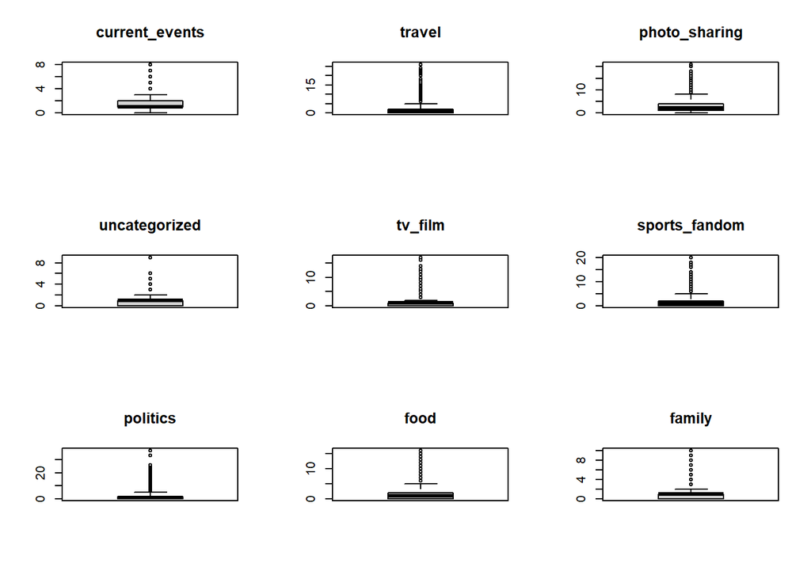

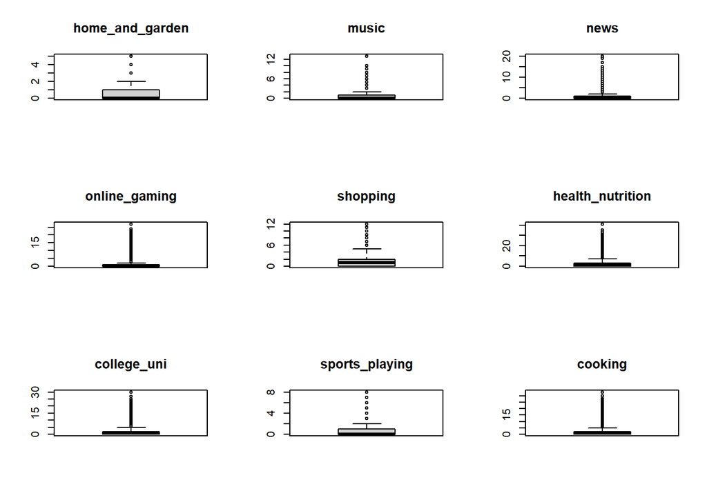

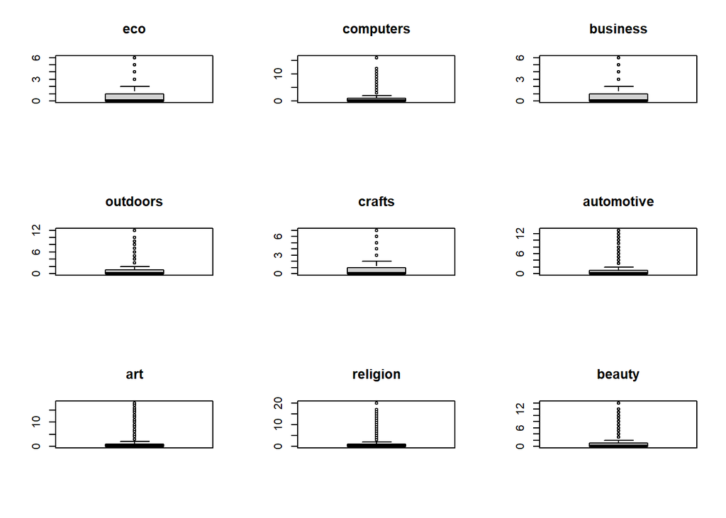

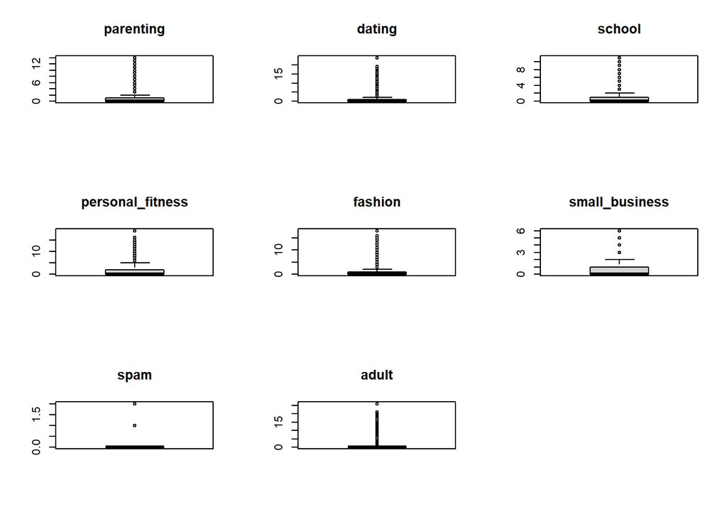

From the below heatmap to understand bi-variate relations, we can infer that only few features have a correlation higher than 0.5

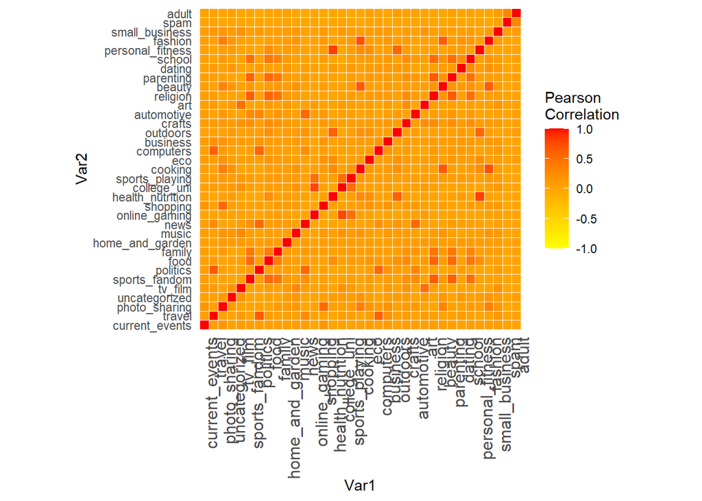

Dropping the “uncategorised” and “chatter” features as they will not reflect the customers’ behavior and are rather a function of the annotators work

As we have a large number of features and ~8K data points, we choose to go ahead with K means clustering. To decide the number of clusters, we are plotting the WSS at different number of clusters ranging from 2 to 15.

We see a clear elbow at K=6, thus we will use this to run the K-Means model

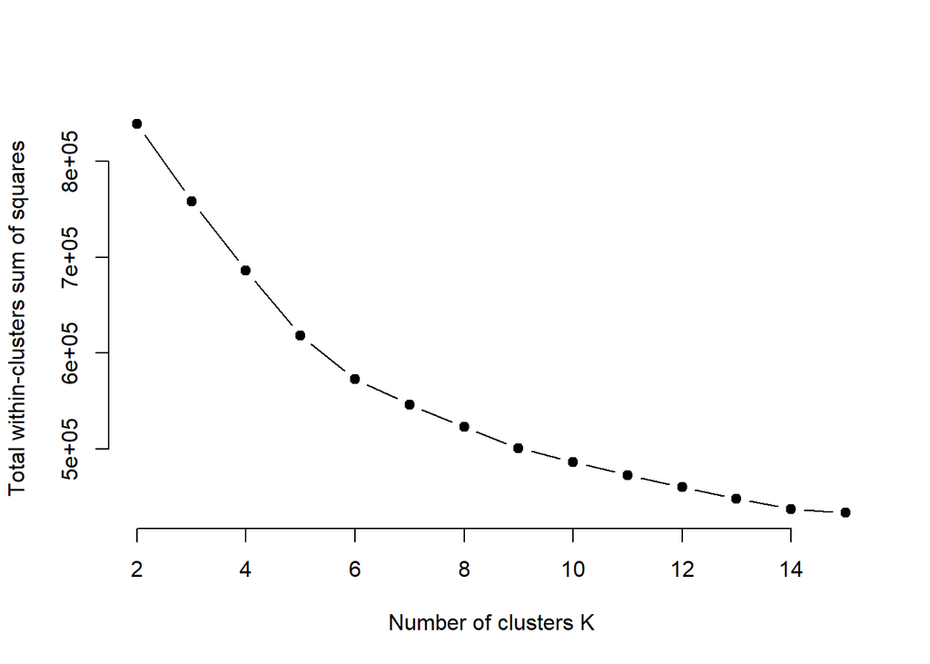

Plotting the clusters on a 2D plot to understand behavior is not possible due to the sheer number of features.

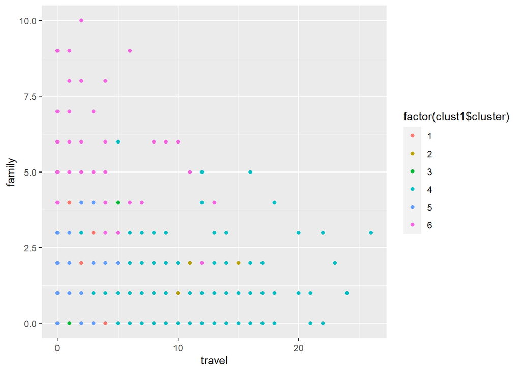

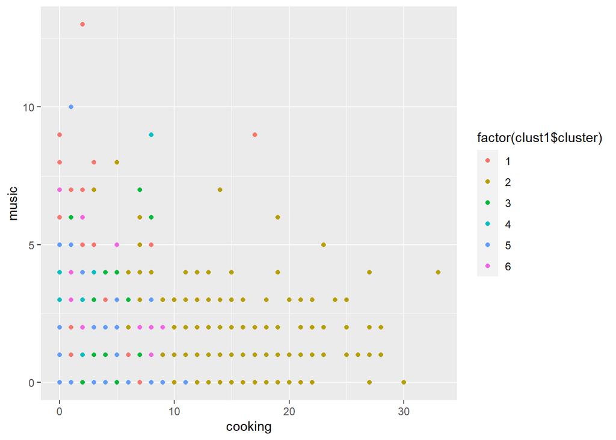

Here, we are plotting the difference between the mean of the population and the mean of each cluster to understand how the behavioral characteristics of the cluster differ from the complete population and set the cluster population apart from the population.

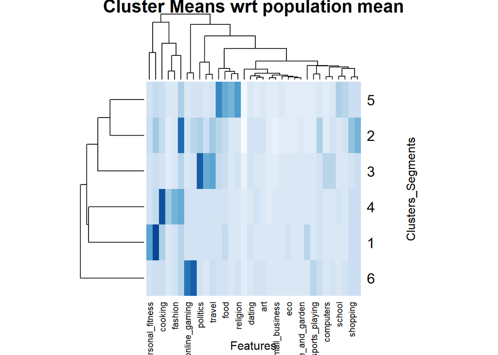

```
##   fixed.acidity volatile.acidity citric.acid residual.sugar chlorides
## 1           7.4             0.70        0.00            1.9     0.076
## 2           7.8             0.88        0.00            2.6     0.098
## 3           7.8             0.76        0.04            2.3     0.092
## 4          11.2             0.28        0.56            1.9     0.075
## 5           7.4             0.70        0.00            1.9     0.076
## 6           7.4             0.66        0.00            1.8     0.075
##   free.sulfur.dioxide total.sulfur.dioxide density   pH sulphates alcohol
## 1                  11                   34  0.9978 3.51      0.56     9.4
## 2                  25                   67  0.9968 3.20      0.68     9.8
## 3                  15                   54  0.9970 3.26      0.65     9.8
## 4                  17                   60  0.9980 3.16      0.58     9.8
## 5                  11                   34  0.9978 3.51      0.56     9.4
## 6                  13                   40  0.9978 3.51      0.56     9.4
##   quality color
## 1       5   red
## 2       5   red
## 3       5   red
## 4       6   red
## 5       5   red
## 6       5   red
```

```
## [1] 6497   13
```

```
##  [1] "fixed.acidity"        "volatile.acidity"     "citric.acid"
##  [4] "residual.sugar"       "chlorides"            "free.sulfur.dioxide"
##  [7] "total.sulfur.dioxide" "density"              "pH"
## [10] "sulphates"            "alcohol"              "quality"
## [13] "color"
```

The below pairwise plots help understand the bi-variate relation between the available X variables.

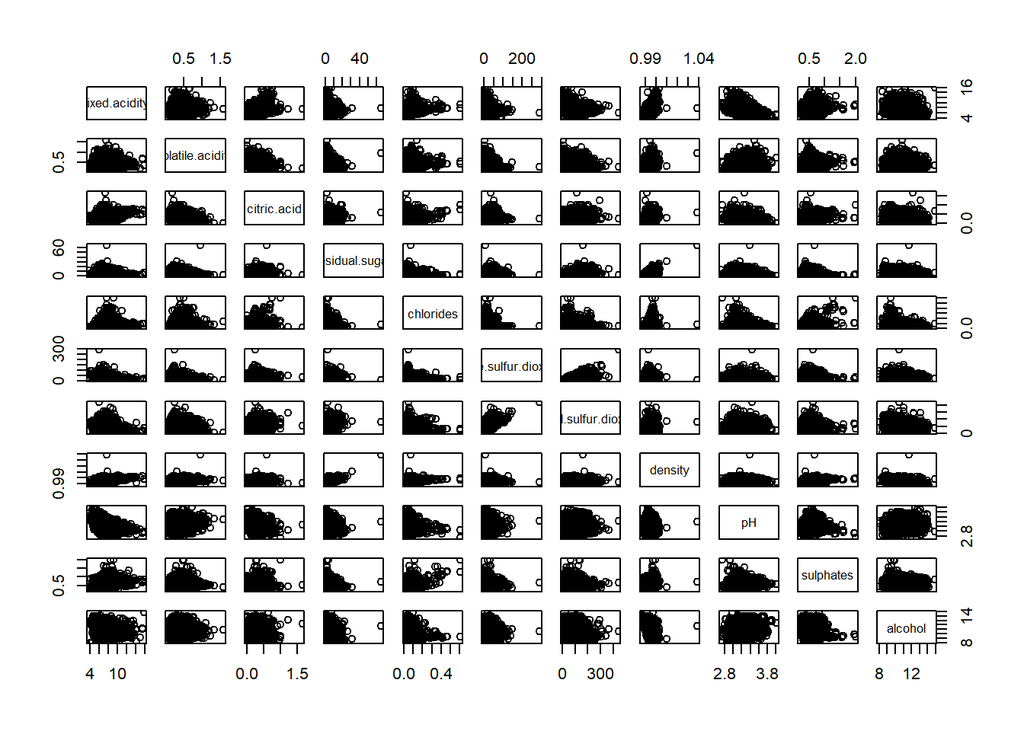

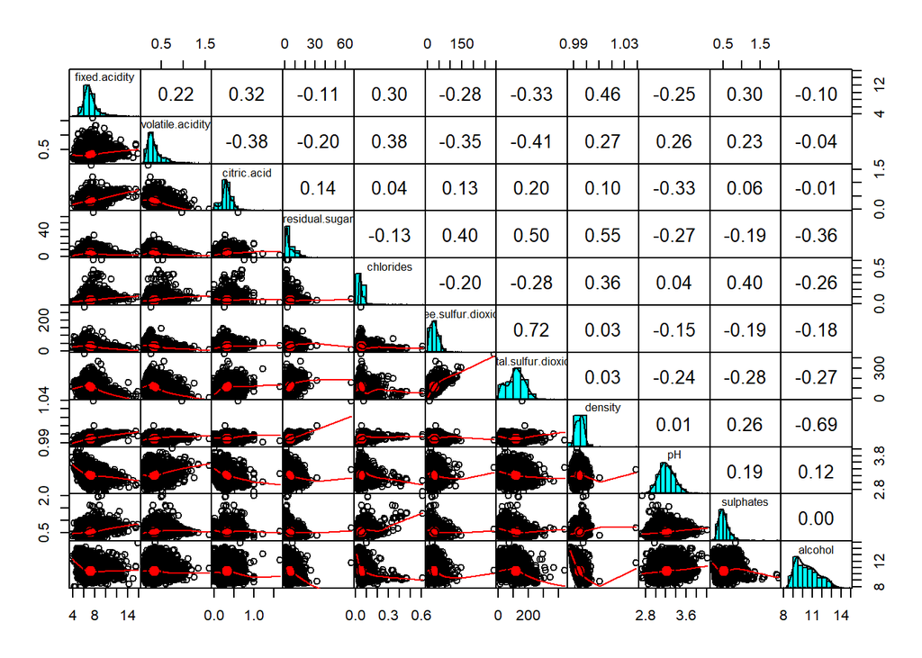

High covariance between X variables helps in achieving better Principal Components. Below table help us understand the same.

```
##                      fixed.acidity volatile.acidity   citric.acid
## fixed.acidity           1.68074049     0.0467451842  6.112206e-02
## volatile.acidity        0.04674518     0.0271051686 -9.043060e-03
## citric.acid             0.06112206    -0.0090430597  2.111728e-02
## residual.sugar         -0.69072041    -0.1535371274  9.848991e-02
## chlorides               0.01354363     0.0021751806  1.985392e-04
## free.sulfur.dioxide    -6.50600262    -1.0302424657  3.433720e-01
## total.sulfur.dioxide  -24.11203016    -3.8569326160  1.603646e+00
## density                 0.00178405     0.0001339362  4.190011e-05
## pH                     -0.05267540     0.0069210740 -7.706052e-03
## sulphates               0.05779170     0.0055363458  1.215219e-03
## alcohol                -0.14759400    -0.0073912113 -1.818756e-03
##                      residual.sugar     chlorides free.sulfur.dioxide
## fixed.acidity          -0.690720406  1.354363e-02         -6.50600262
## volatile.acidity       -0.153537127  2.175181e-03         -1.03024247
## citric.acid             0.098489906  1.985392e-04          0.34337205
## residual.sugar         22.636696458 -2.149219e-02         34.02168454
## chlorides              -0.021492189  1.227353e-03         -0.12128380
## free.sulfur.dioxide    34.021684542 -1.212838e-01        315.04119227
## total.sulfur.dioxide  133.244854379 -5.537142e-01        723.26197160
## density                 0.007882813  3.809423e-05          0.00136877
## pH                     -0.204498058  2.518380e-04         -0.41624898
## sulphates              -0.131634584  2.062309e-03         -0.49775610
## alcohol                -2.039566839 -1.073521e-02         -3.80716486
##                      total.sulfur.dioxide       density            pH
## fixed.acidity               -2.411203e+01  1.784050e-03 -5.267540e-02
## volatile.acidity            -3.856933e+00  1.339362e-04  6.921074e-03
## citric.acid                  1.603646e+00  4.190011e-05 -7.706052e-03
## residual.sugar               1.332449e+02  7.882813e-03 -2.044981e-01
## chlorides                   -5.537142e-01  3.809423e-05  2.518380e-04
## free.sulfur.dioxide          7.232620e+02  1.368770e-03 -4.162490e-01
## total.sulfur.dioxide         3.194720e+03  5.490564e-03 -2.166696e+00
## density                      5.490564e-03  8.992040e-06  5.634423e-06
## pH                          -2.166696e+00  5.634423e-06  2.585252e-02
## sulphates                   -2.319079e+00  1.157845e-04  4.596760e-03
## alcohol                     -1.791465e+01 -2.456181e-03  2.325216e-02
##                          sulphates       alcohol
## fixed.acidity         0.0577916979 -1.475940e-01
## volatile.acidity      0.0055363458 -7.391211e-03
## citric.acid           0.0012152190 -1.818756e-03
## residual.sugar       -0.1316345842 -2.039567e+00
## chlorides             0.0020623093 -1.073521e-02
## free.sulfur.dioxide  -0.4977561009 -3.807165e+00
## total.sulfur.dioxide -2.3190787089 -1.791465e+01
## density               0.0001157845 -2.456181e-03
## pH                    0.0045967600  2.325216e-02
## sulphates             0.0221431880 -5.376291e-04
## alcohol              -0.0005376291  1.422561e+00
```

The below table helps us get a sense of the 11 Principal Components formed and the variability explained by them. We can see that the first 4 components can explain 73% variability in the data. After which each additional feature gives a lesser incremental value in variance explainability.

```
## Importance of components:
##                           PC1    PC2    PC3     PC4     PC5     PC6     PC7
## Standard deviation     1.7407 1.5792 1.2475 0.98517 0.84845 0.77930 0.72330
## Proportion of Variance 0.2754 0.2267 0.1415 0.08823 0.06544 0.05521 0.04756
## Cumulative Proportion  0.2754 0.5021 0.6436 0.73187 0.79732 0.85253 0.90009
##                            PC8     PC9   PC10    PC11
## Standard deviation     0.70817 0.58054 0.4772 0.18119
## Proportion of Variance 0.04559 0.03064 0.0207 0.00298
## Cumulative Proportion  0.94568 0.97632 0.9970 1.00000
```

```
## [1] 6497   11
```

```
##         PC1       PC2      PC3       PC4        PC5        PC6         PC7
## 1 -3.205749 0.4164913 2.722027 0.7967162 -0.2028619  0.2273453 -0.32552850
## 2 -3.038817 1.1073769 2.046795 0.7701656  1.3225536 -1.6549941  0.05955408
## 3 -3.071657 0.8788968 1.742445 0.8021955  0.7620531 -0.8483083  0.16765673
##         PC8         PC9       PC10        PC11 fixed.acidity volatile.acidity
## 1 0.5672348  0.07122341 0.10803795  0.02745798           7.4             0.70
## 2 0.5145630 -0.42909559 0.26812827 -0.01547017           7.8             0.88
## 3 0.4209200 -0.27101087 0.08682522  0.05414179           7.8             0.76
##   citric.acid residual.sugar chlorides free.sulfur.dioxide total.sulfur.dioxide
## 1        0.00            1.9     0.076                  11                   34
## 2        0.00            2.6     0.098                  25                   67
## 3        0.04            2.3     0.092                  15                   54
##   density   pH sulphates alcohol quality color
## 1  0.9978 3.51      0.56     9.4       5   red
## 2  0.9968 3.20      0.68     9.8       5   red
## 3  0.9970 3.26      0.65     9.8       5   red
```

To get a visual sense of the the PCs and their differentiation of the Wine Color, we have plotted the below scatter plot with PC1 and PC2 (Since they explain 50% variability). We can see a clear distinction between red and white wines.

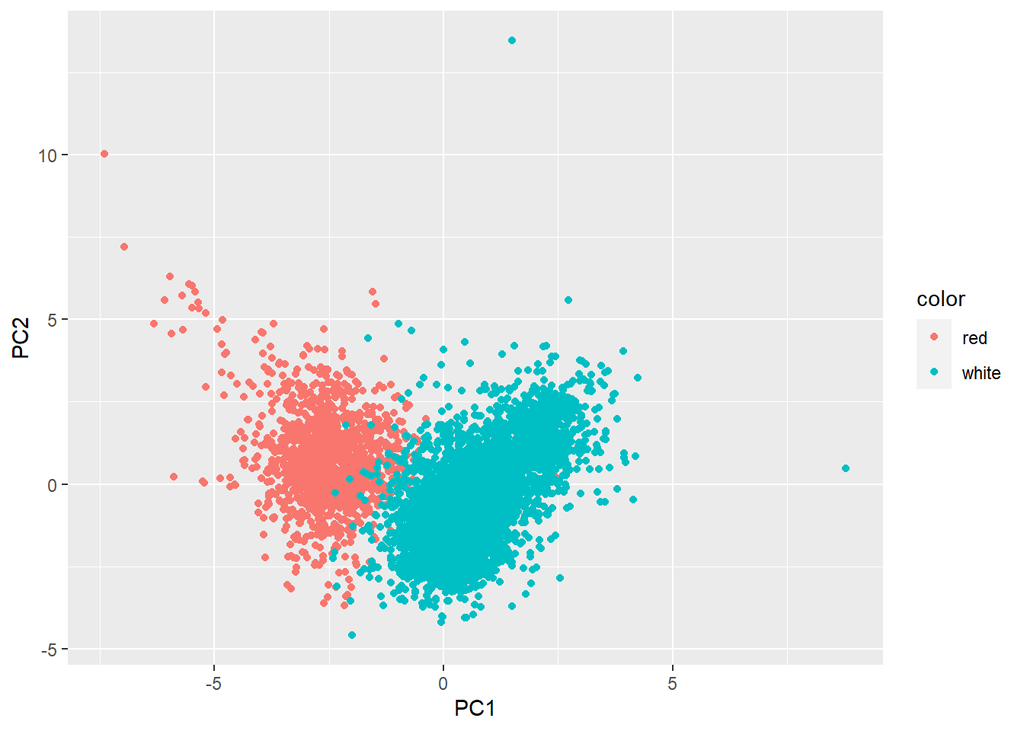

However, no clear differentiation is observed in Wine Quality basis PC1 And PC2

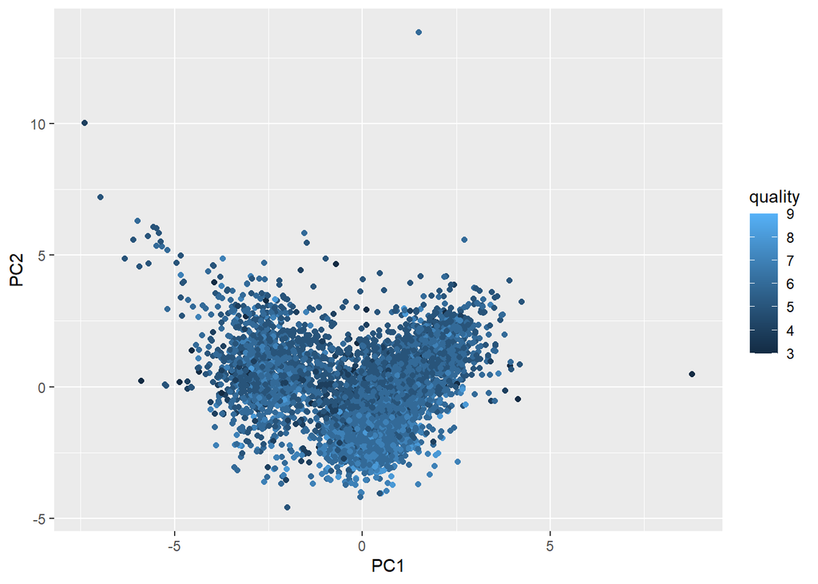